# Algotitma Self Organizing Map Dengan R

### STUDY KASUS

1. Memanggil data iris dengan syntax seperti berikut.

```r
data("iris")
View(iris)
```

Berdasarkan data iris diatas dapat diketahui bahwa terdapat 5 variabel yaitu Sepal.Length, Sepal.Width, Petal.Length, Petal.Width dan species(sebagai label)

2. Melakukan standarisasi atau penghapusan pada Variabel species(label)

```r
scale(iris[,-5])
```

[output not shown]

[output cut: 142 more lines]

```r
head(scale(iris[,-5]))
```

```
##      Sepal.Length Sepal.Width Petal.Length Petal.Width
## [1,]   -0.8976739  1.01560199    -1.335752   -1.311052
## [2,]   -1.1392005 -0.13153881    -1.335752   -1.311052
## [3,]   -1.3807271  0.32731751    -1.392399   -1.311052
## [4,]   -1.5014904  0.09788935    -1.279104   -1.311052
## [5,]   -1.0184372  1.24503015    -1.335752   -1.311052
## [6,]   -0.5353840  1.93331463    -1.165809   -1.048667
```

3. Melihat dimensi dari data iris dengan syntax seperti berikut.

```r
dim(iris)
```

```
## [1] 150   5
```

Berdasarkan hasil output diatas dapat diketahui bahwa dimensi data yang ada yaitu 150 baris dan 5 kolom.

4. Melihat struktur dari data iris dengan syntax seperti berikut.

```r
str(iris)
```

```
## 'data.frame':    150 obs. of  5 variables:
##  $ Sepal.Length: num  5.1 4.9 4.7 4.6 5 5.4 4.6 5 4.4 4.9 ...
##  $ Sepal.Width : num  3.5 3 3.2 3.1 3.6 3.9 3.4 3.4 2.9 3.1 ...
##  $ Petal.Length: num  1.4 1.4 1.3 1.5 1.4 1.7 1.4 1.5 1.4 1.5 ...
##  $ Petal.Width : num  0.2 0.2 0.2 0.2 0.2 0.4 0.3 0.2 0.2 0.1 ...
##  $ Species     : Factor w/ 3 levels "setosa","versicolor",..: 1 1 1 1 1 1 1 1 1 1 ...
```

### PENGELOMPOKAN

1. membuat kelompok atau clustering dari data iris dengan syntax berikut:

```r
grid<- somgrid(xdim=5 , ydim=5 , topo = "hexagonal")
```

2. Kwmudian selanjutnya melakukan perintah SOM dari data iris dengan syntax seperti berikut.

```r
som.iris <- som(as.matrix(iris[,-5]), grid = somgrid(xdim = 4, ydim = 4, topo="hexagonal"))
```

3. Melihat struktur data setelah adanya cara kerja SOM pada data iris dengan syntax seperti berikut.

```r
str(som.iris)
```

```
## List of 14
##  $ data            :List of 1
##   ..$ : num [1:150, 1:4] 5.1 4.9 4.7 4.6 5 5.4 4.6 5 4.4 4.9 ...
##   .. ..- attr(*, "dimnames")=List of 2
##   .. .. ..$ : NULL
##   .. .. ..$ : chr [1:4] "Sepal.Length" "Sepal.Width" "Petal.Length" "Petal.Width"
##  $ unit.classif    : num [1:150] 3 4 4 4 3 3 4 3 4 4 ...
##  $ distances       : num [1:150] 0.0678 0.0566 0.0179 0.018 0.0792 ...
##  $ grid            :List of 6
##   ..$ pts              : num [1:16, 1:2] 1.5 2.5 3.5 4.5 1 2 3 4 1.5 2.5 ...
##   .. ..- attr(*, "dimnames")=List of 2
##   .. .. ..$ : NULL
##   .. .. ..$ : chr [1:2] "x" "y"
##   ..$ xdim             : num 4
##   ..$ ydim             : num 4
##   ..$ topo             : chr "hexagonal"
##   ..$ neighbourhood.fct: Factor w/ 2 levels "bubble","gaussian": 1
##   ..$ toroidal         : logi FALSE
##   ..- attr(*, "class")= chr "somgrid"
##  $ codes           :List of 1
##   ..$ : num [1:16, 1:4] 7.6 6.53 5.23 4.7 6.7 ...
##   .. ..- attr(*, "dimnames")=List of 2
##   .. .. ..$ : chr [1:16] "V1" "V2" "V3" "V4" ...
##   .. .. ..$ : chr [1:4] "Sepal.Length" "Sepal.Width" "Petal.Length" "Petal.Width"
##  $ changes         : num [1:100, 1] 0.0365 0.0315 0.0255 0.0295 0.0339 ...
##  $ alpha           : num [1:2] 0.05 0.01
##  $ radius          : Named num [1:2] 2.65 0
##   ..- attr(*, "names")= chr [1:2] "66.66667%" ""
##  $ na.rows         : int(0)
##  $ user.weights    : num 1
##  $ distance.weights: num 1
##  $ whatmap         : int 1
##  $ maxNA.fraction  : int 0
##  $ dist.fcts       : chr "sumofsquares"
##  - attr(*, "class")= chr "kohonen"
```

### PLOT

Melihat hasil plot dari data dengan syntax seperti berikut.

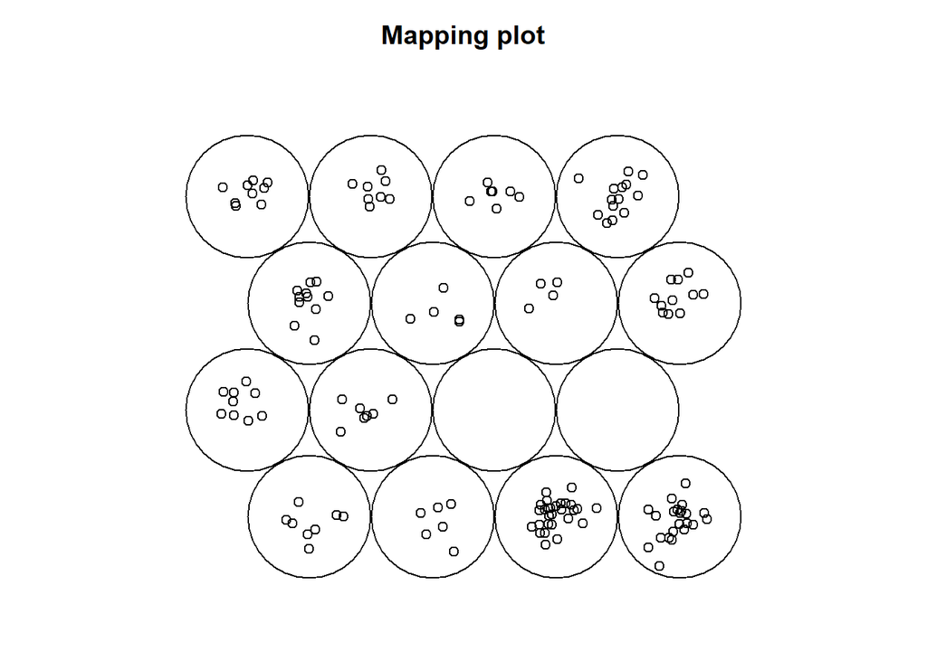

```r
plot(som.iris, type="mapping")
```

Berdasarkan hasil output diatas dapat diketahui bahwa dimensi dari letak gambar yaitu 4x4 maka terdapat sebanyak 16 lingkaran yang menyatakan data sudah terkumpul pada masing-masing lingkaran tersebut.

1. Untuk mengetahui objek yang masuk didalam lingkaran maka menggunakan syntax seperti berikut.

```r
som.iris$grid$pts
```

```
##         x         y
##  [1,] 1.5 0.8660254
##  [2,] 2.5 0.8660254
##  [3,] 3.5 0.8660254
##  [4,] 4.5 0.8660254
##  [5,] 1.0 1.7320508
##  [6,] 2.0 1.7320508
##  [7,] 3.0 1.7320508
##  [8,] 4.0 1.7320508
##  [9,] 1.5 2.5980762
## [10,] 2.5 2.5980762
## [11,] 3.5 2.5980762
## [12,] 4.5 2.5980762
## [13,] 1.0 3.4641016
## [14,] 2.0 3.4641016
## [15,] 3.0 3.4641016
## [16,] 4.0 3.4641016
```

Berdasarkan hasil output diatas dapat diketahui bahwa pada lingkaran pertama sumbu x bernilai 1.5 dan sumbu y bernilai 0.8660254 , pada lingkaran kedua sumbu x bernilai 2.5 dan sumbu y bernilai 0.8660254 dan seterusnya.

2. Untuk melihat letak nomer objek berapa yang masuk dalam lingkaran maka digunakan syntax seperti berikut.

```r
som.iris$unit.classif
```

```
##   [1]  3  4  4  4  3  3  4  3  4  4  3  4  4  4  3  3  3  3  3  3  3  3  4  3  4
##  [26]  4  3  3  3  4  4  3  3  3  4  4  3  3  4  3  3  4  4  3  3  4  3  4  3  4
##  [51] 10  2 10 12  2 16 15 12  2 12 12 16 11 15 12  2 16 16 11 12 13 11 14 15  2
##  [76]  2 10 10 15 12 12 12 16 14 16 15 10 11 16 16 16 15 16 12 16 16 16 15 12 16
## [101]  5 13  6  9  5  1 16  1  6  5  9  9  6 13 13  9  9  1  1 14  5 13  1 14  5
## [126]  6 14 13  9  6  1  1  9 14 14  1  5  9 13  6  5  6 13  5  5  9 14  9  9 13
```

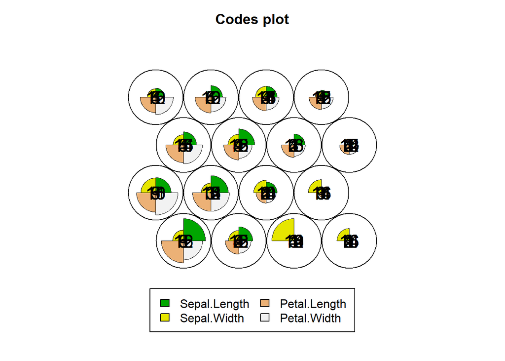

```r
plot(som.iris)
text(som.iris$grid$pts, labels = som.iris$unit.classif,cex=1.5)
```

Berdasarkan hasil plot diatas dapat diketahui bahwa dari semua 4 variabel yang ada tidak ada satupun variabel yang direduksi. Pada warna hijau mewakili variabel Sepal.Lengh , pada warna kuning mewakili variabel Sepal.Width , dan seterusnya.

Berdasarkan plot diatas dapat diketahui bahwa terlihat nilai-nilai dari nomor objeknya. Dalam satu lingkaran terdapat beberapa objek sehingga beberapa angka bertumpukkan menjadi satu.

4. Selanjutnya melihat hasil pengelompokkan dari beberapa objek didalam masing-masing lingkaran dengan syntax seperti berikut.

```r
som.iris$codes[[1]]
```

```
##     Sepal.Length Sepal.Width Petal.Length Petal.Width
## V1      7.596288    3.036567     6.442508   2.0612915
## V2      6.531583    3.010195     4.467448   1.4060566
## V3      5.233665    3.676200     1.510433   0.2815051
## V4      4.695767    3.121883     1.408706   0.2006143
## V5      6.696463    3.273482     5.785704   2.3522494
## V6      6.954286    2.989448     5.602956   1.9870789
## V7      6.112445    3.148558     3.736608   1.1606409
## V8      5.248579    3.179061     2.228340   0.5589588
## V9      6.410391    3.015162     5.410930   2.0426109
## V10     6.797467    3.037221     4.812178   1.5006571
## V11     6.137053    2.442753     4.236248   1.2963240
## V12     5.315109    2.456254     3.571880   1.1188942
## V13     5.865528    2.906653     4.955612   1.9099941
## V14     6.191934    2.570443     5.038049   1.6389625
## V15     6.104282    3.043435     4.556200   1.4512846
## V16     5.597656    2.790603     4.252915   1.3378201
```

5. Melakukan pengelompokkan berdasarkan nilai codes menggunakan cluster hierarki dengan syntax seperti berikut.

```r
dist(som.iris$codes[[1]])
```

```
##            V1        V2        V3        V4        V5        V6        V7
## V2  2.3376236
## V3  5.7865469 3.4837787
## V4  6.1009494 3.7671864 0.7832576
## V5  1.1755261 1.6521452 4.9867711 5.2738421
## V6  1.0605383 1.3439021 4.8051948 5.0893652 0.5602627
## V7  3.2167374 0.8883571 2.6037274 2.8893712 2.4444648 2.2136550
## V8  5.0545282 2.7213593 0.9163737 1.0531295 4.2398125 4.0463501 1.8395888
## V9  1.5720404 1.1445838 4.4874304 4.7288558 0.6204009 0.5800351 1.9203627
## V10 1.9001063 0.4463314 3.9040519 4.2069038 1.3187053 0.9427680 1.3244290
## V11 2.8168673 0.7369796 3.2859436 3.4255065 2.1257570 1.8198295 0.8756800
## V12 3.8300342 1.6343704 2.5388353 2.5197628 2.9996973 2.8018234 1.0695361
## V13 2.2904487 0.9729375 3.9386157 4.1130513 1.3075385 1.2717090 1.4720692
## V14 2.0833508 0.8298032 4.0531152 4.2170576 1.3478058 1.0940986 1.5043520
## V15 2.4812086 0.4400158 3.4356144 3.6689184 1.6513684 1.4519628 0.8759691
## V16 3.0614961 0.9854556 3.0909192 3.2102822 2.1952354 2.0307963 0.8313272
##            V8        V9       V10       V11       V12       V13       V14
## V2
## V3
## V4
## V5
## V6
## V7
## V8
## V9  3.7022660
## V10 3.1594592 0.8958420
## V11 2.4304187 1.5294410 1.0784179
## V12 1.6265001 2.3973698 2.0540179 1.0717467
## V13 3.1173937 0.7304458 1.0361886 1.0876606 1.7453873
## V14 3.2126630 0.7399135 0.8091340 0.8829510 1.7894088 0.5475690
## V15 2.6392797 1.0838512 0.7406118 0.6987668 1.4307151 0.6675758 0.7062621
## V16 2.2312065 1.5964635 1.3563397 0.6433884 0.8386653 0.9520454 1.0529760
##           V15
## V2
## V3
## V4
## V5
## V6
## V7
## V8
## V9
## V10
## V11
## V12
## V13
## V14
## V15
## V16 0.6522656
```

```r
hclust(dist(som.iris$codes[[1]]))
```

```
##
## Call:
## hclust(d = dist(som.iris$codes[[1]]))
##
## Cluster method   : complete
## Distance         : euclidean
## Number of objects: 16
```

Berdasarkan hasil diatas dapat diketahui bahwa pengelompokkan yang dilakukan dengan cluster hierarki menggunakan metode complete , dan menggunakan distance yaitu euclidean dengan objek sebanyak 16.

6. Kemudian membuat plot hasil pengelompokkan dengan syntax seperti berikut.

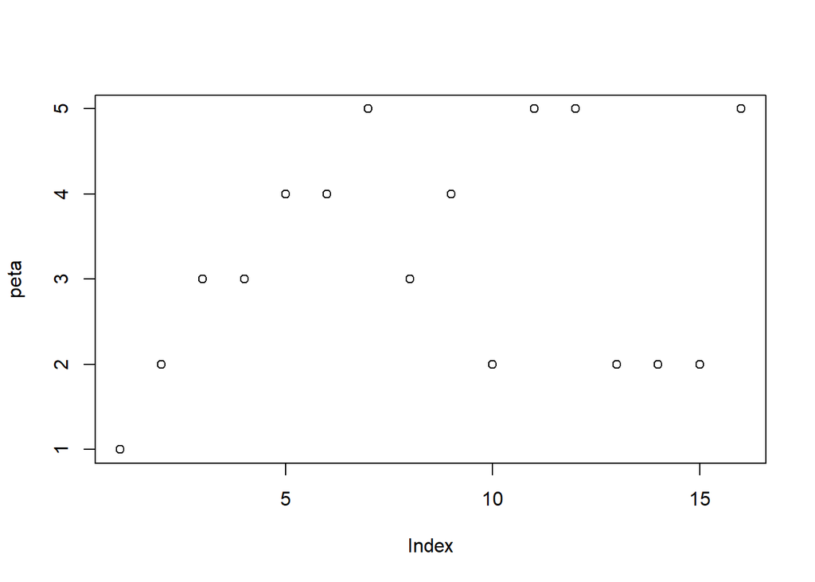

```r
peta <- cutree(hclust(dist(som.iris$codes[[1]])),5)
plot(peta)
```

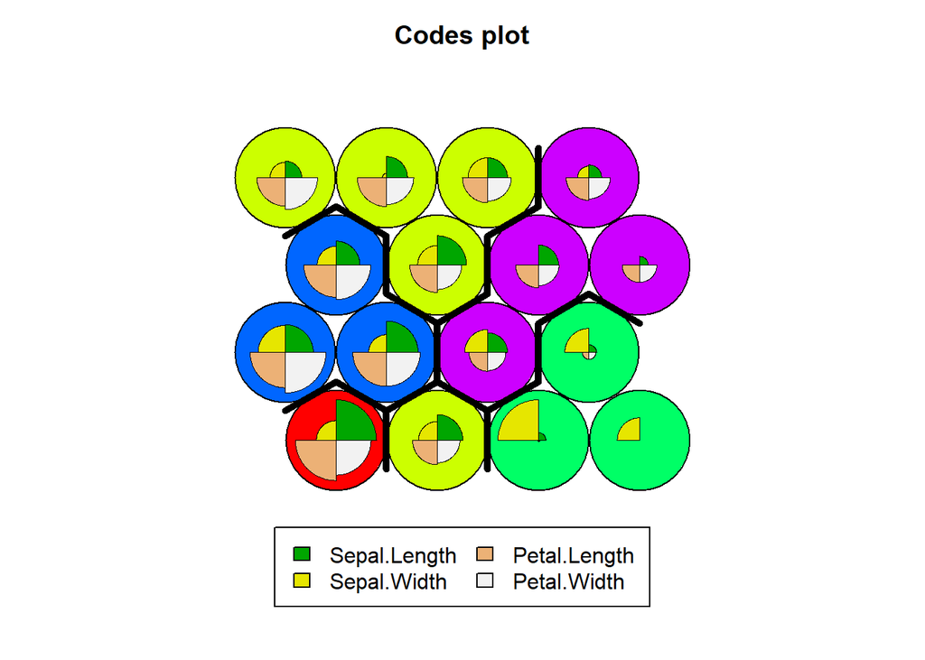

```r
plot(som.iris,type="codes",bgcol=rainbow(5)[peta])
add.cluster.boundaries(som.iris,peta)
```

~~~~~ THANK YOU ~~~~~

# REFRENSI

1. https://medium.com/@16611130/penerapan-self-organizing-map-som-pada-r-menggunakan-data-wines-7c83130fc 1a0
2. https://github.com/DianI5lami79/Alogaritma-SOM
3. https://socs.binus.ac.id/2017/03/20/self-organizing-map-som/
4. https://algorit.ma/blog/self-organizing-maps-som-2022/
5. https://www.researchgate.net/publication/331741192_Self_Organizing_MapsSOM_untuk_Pengelompokkan_Jurusa n_di_SMK